# Tarea 5

Matías Astudillo, Alex den Braber y Nicolas Paris

16-11-2018

# Pregunta 2

## Base

```r
tickers <- c("MSFT","AAPL")
data_activos <- tq_get(tickers,
                       get = "stock.prices",
                       from = "2000-01-01",
                       to  = "2018-08-30",
                       periodicity = "monthly")
```

## Función

```r
finance = function(x,return=c('yes','no'),plot=c('type 1','type 2'),normal=c('yes','no')){
  r = "Solo puede ser yes o no entre comillas"
  fplot = "Solo existen dos tipo de formato, type 1 que corresponde a retornos, type 2 que corresponde a retornos acumulados. Favor ingresa el tipo entre comillas"

  #Para retornos logaritmicos
  if (return=='yes'){
    #Retornos
    retornos_activos_log <- x %>%
      group_by(symbol) %>%
      tq_transmute(select = close,
                   mutate_fun = periodReturn,
                   period = "monthly",
                   type = "log",
                   col_rename = "retornos.diarios")

    #Graficos
    ifelse(plot=='type 1',
           (g11 <- retornos_activos_log %>%
              ggplot(mapping = aes(x = retornos.diarios, fill = symbol))+
              geom_density(alpha = 0.5) +
              labs(title = "Retornos Activos",
                   subtitle = "Apple & Microsoft",
                   x = "Retornos mensuales", y = "Densidad") +
              theme_tq() +
              scale_fill_tq() +
              facet_wrap(~ symbol, ncol = 2) +
              guides(fill=guide_legend(title="Activos:"))),
           ifelse(plot=='type 2',
                  (g12 <- retornos_activos_log %>%
                     group_by(symbol) %>%
                     mutate(ret.cum = cumsum(retornos.diarios))  %>%
                     ggplot(mapping = aes(x = date, y = ret.cum/100, color = symbol)) +
                     geom_line() +
                     labs(title = "Retornos Activos",
                          subtitle = "Apple & Microsoft",
                          x = "Periodo", y = "Retorno Acumulado") +
                     theme_tq() +
                     scale_fill_tq() +
                     facet_wrap(~ symbol, ncol = 2) +
                     guides(color = guide_legend(title="Activos:")) +
                     scale_y_continuous(labels = scales::percent))
                  ,fplot))

    #Test Normalidad
    if(normal=='yes'){
      j_log = by(retornos_activos_log,retornos_activos_log$symbol,
                 function(x){
                   n=length(x$retornos.diarios)
                   mean = sum(x$retornos.diarios)/n
                   skewness = ((sum(x$retornos.diarios-mean)^3)/n)/((sum(x$retornos.diarios-mean)^2)/n)^(3/2)
                   kurtosis = ((sum(x$retornos.diarios-mean)^4)/n)/((sum(x$retornos.diarios-mean)^2)/n)^2
                   JB = n*(((skewness^2)/6)+(((kurtosis-3)^2)/24))
                   j = paste('p-value =',1 - pchisq(JB,df = 2),ifelse(1 - pchisq(JB,df = 2)<0.05,
                                                                      ', entonces rechazamos la hipotesis nula de normalidad',
                                                                      ', entonces no rechazamos  la hipotesis nula de normalidad'))

                 }
      )
    }
  }

  #Para retornos atirmeticos
  else if (return=='no'){

    #Retornos
    retornos_activos_arit <- x %>%
      group_by(symbol) %>%
      tq_transmute(select = close,
                   mutate_fun = periodReturn,
                   period = "monthly",
                   type = "arithmetic",
                   col_rename = "retornos.diarios")

    #Graficos
    ifelse(plot=='type 1',
           (g21 <- retornos_activos_arit %>%
              ggplot(mapping = aes(x = retornos.diarios, fill = symbol))+
              geom_density(alpha = 0.5) +
              labs(title = "Retornos Activos",
                   subtitle = "Apple & Microsoft",
                   x = "Retornos mensuales", y = "Densidad") +
              theme_tq() +
              scale_fill_tq() +
              facet_wrap(~ symbol, ncol = 2) +
              guides(fill=guide_legend(title="Activos:"))),
           ifelse(plot=='type 2',
                  (g22 <- retornos_activos_arit %>%
                     group_by(symbol) %>%
                     mutate(ret.cum = cumsum(retornos.diarios))  %>%
                     ggplot(mapping = aes(x = date, y = ret.cum/100, color = symbol)) +
                     geom_line() +
                     labs(title = "Retornos Activos",
                          subtitle = "Apple & Microsoft",
                          x = "Periodo", y = "Retorno Acumulado") +
                     theme_tq() +
                     scale_fill_tq() +
                     facet_wrap(~ symbol, ncol = 2) +
                     guides(color = guide_legend(title="Activos:")) +
                     scale_y_continuous(labels = scales::percent))
                  ,fplot))

    #Test Normalidad
    if (normal=='yes'){
      j_arit= by(retornos_activos_arit,retornos_activos_arit$symbol,
                 function(x){
                   n=length(x$retornos.diarios)
                   mean = sum(x$retornos.diarios)/n
                   skewness = ((sum(x$retornos.diarios-mean)^3)/n)/((sum(x$retornos.diarios-mean)^2)/n)^(3/2)
                   kurtosis = ((sum(x$retornos.diarios-mean)^4)/n)/((sum(x$retornos.diarios-mean)^2)/n)^2
                   JB = n*(((skewness^2)/6)+(((kurtosis-3)^2)/24))
                   j = paste('p-value =',1 - pchisq(JB,df = 2),ifelse(1 - pchisq(JB,df = 2)<0.05,
                                                                      ', entonces rechazamos la hipotesis nula de normalidad',
                                                                      ', entonces no rechazamos  la hipotesis nula de normalidad'))

                 }
      )
    }
  }

  n="No realiza Test de Normalidad"
  #return

  ifelse(return=="yes"& plot=='type 1' & normal=="yes",return(list(g11,j_log)),
         ifelse(return=='yes' & plot=='type 2' & normal=="yes",return(list(g12,j_log)),
                ifelse(return=='yes' & plot=='type 1' & normal=="no",return(list(g11,n)),
                       ifelse(return=='yes' & plot=='type 2' & normal=="no",return(list(g12,n)),
                              ifelse(return=='no' & plot=='type 1' & normal=="yes",return(list(g21,j_arit)),
                                     ifelse(return=='no' & plot=='type 2' & normal=="yes",return(list(g22,j_arit)),
                                            ifelse(return=='no' & plot=='type 1' & normal=="no",return(list(g21,n)),
                                                   ifelse(return=='no' & plot=='type 2' & normal=="no",return(list(g22,n)),"Algo esta mal"))))))

         ))
}
```

## Pruebas

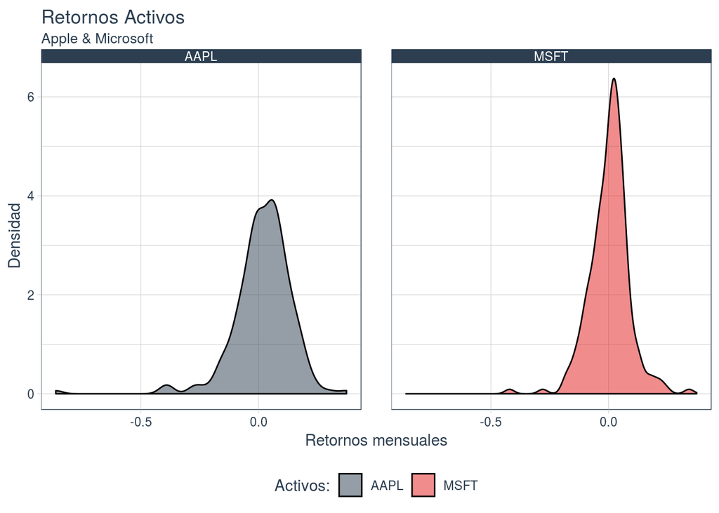

```
##
## [[2]]
## retornos_activos_log$symbol: AAPL
## [1] "p-value = 0 , entonces rechazamos la hipotesis nula de normalidad"
## --------------------------------------------------------
## retornos_activos_log$symbol: MSFT
## [1] "p-value = 0 , entonces rechazamos la hipotesis nula de normalidad"
```

```r
finance(data_activos,"yes","type 1","yes")
```

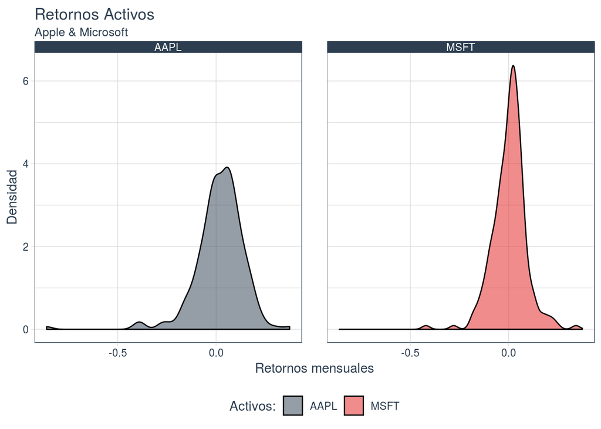

```
##
## [[2]]
## [1] "No realiza Test de Normalidad"
```

```r
finance(data_activos,"yes","type 1","no")
```

# Pregunta 3

## Parte a

Dado que se explicita que el modelo real va depender de dos variables, especificarlo solo con una variable explicativa necesariamente producirá una endogeneidad, por variable omitida relevante (VOR). Este problema se va a podrudcir ya que no se cumple el criterio de $E(\epsilon,X_i)\neq 0$. La implicancia de este problema es que el estimador MCO ya no podra considerarse MELI, debido a que estará sesgado y será incosistente. Esto puede ser demostrado matemáticamente.

$$\hat{\beta}_1={({X_1}'{X_1)}}^{-1}{X_1}'(X_1\beta_1+X_2\beta_2+\varepsilon)$$

$$\beta_1 + {({X_1}'{X_1)}}^{-1}{X_1}'X_2\beta_2 + {({X_1}'X_1)}^{-1}{X_1}'+\varepsilon\setminus E()$$

$$\beta_1 + \underbrace{ {({X_1}'{X_1})}^{-1}{X_1}'{X_2} }_{\hat{\gamma} \Rightarrow Sesgo=corr(X_2,X_1)}\beta_2 \neq \beta_1 +\beta_2$$

$$\left .
\begin{matrix}
\beta_2\Rightarrow corr(Y,X_2)\Rightarrow Direcci\acute{o}n \\
\hat{\gamma}\Rightarrow corr(X_1,X_2)\Rightarrow Direcci\acute{o}n
{}
\end{matrix}
\right \} Magnitud$$
$$\left.
\begin{matrix}
\hat{\beta_2}>0\\
\hat{\gamma}>0
{}
\end{matrix}
\right \} Sobreestimado$$
$$\left .
\begin{matrix}
\hat{\beta_2}<0\\
\hat{\gamma}<0
{}
\end{matrix}
\right
\}
Sobreestimado$$

En la medida que ambos signos sean $\neq$ se estará subestimando la magnitud del efecto. Además los estimadores no serán consistentes, es decir que independiente que se aumente la muestra, los valores no convergeran al valor real. Para poder comprobar esta propiedad, podemos evaluar las esperanzas de ambos modelos, sopensado para cada tamaño muestral. Lo que deberíamos esperar del modelo correcto es que a medida que se aumente la muestra el valor sea cercano al valor poblacional. Respecto al modelo incorrecto, se espera que a medida que aumente la muestra se tienda a un valor de $\beta_1$ equivocado, el cual permitirá medir la magnitud del sesgo.

```r
set.seed(123)
reps=10000
betas1=matrix(NA, nrow= reps, ncol=16)
betas2=matrix(NA, nrow= reps, ncol=16)
beta0=2
beta1=2.5
beta2=1
su=1
n = c(50, 100, 500, 1000) #Tamaño Muestral
for(j in 1:length(n)) {
x1=rnorm(n[j],20,1)
x21=(0.8*x1)+rnorm(n[j],0,1)
x22=runif(n[j],0,1)

for(i in 1:reps){
u=rnorm(n[j],0,su)
v1= (beta2*x21)+ u
v2= (beta2*x22)+ u

Y0=beta0+beta1*x1 + v1
Y1=beta0 + beta1*x1 + beta2*x21 + u
Y02=beta0+beta1*x1 + v2
Y12=beta0 + beta1*x1 + beta2*x22 + u
model0= lm(Y0~x1)
betas1[i,j] =model0$coef[1] #beta0 modelo sesgado
betas1[i,j+4] =model0$coef[2] #beta1 modelo sesgado
model1= lm(Y1~x1 +x21)
betas1[i,j+8] = model1$coef[1] #beta0 modelo correcto
betas1[i,j+12] = model1$coef[2] #beta1 modelo correcto

model02= lm(Y02~x1)
betas2[i,j] =model02$coef[1] #beta0 modelo sesgado
betas2[i,j+ 4] =model02$coef[2] #beta1 modelo sesgado
model12= lm(Y12~x1 +x22)
betas2[i,j+8] = model12$coef[1] #beta0 modelo correcto
betas2[i,j+12] = model12$coef[2] #beta1 modelo correcto

}
}
colnames(betas1) = c("50_b0_M1I", "100_b0_M1I", "500_b0_M1I", "1000_b0_M1I",
                    "50_b1_M1I", "100_b1_M1I", "500_b1_M1I", "1000_b1_M1I",
                    "50_b0_M1C", "100_b0_M1C", "500_b0_M1C", "1000_b0_M1C",
                    "50_b1_M1C", "100_b1_M1C", "500_b1_M1C", "1000_b1_M1C")

colnames(betas2) = c("50_b0_M2I", "100_b0_M2I", "500_b0_M2I", "1000_b0_M2I",
                    "50_b1_M2I", "100_b1_M2I", "500_b1_M2I", "1000_b1_M2I",
                    "50_b0_M2C", "100_b0_M2C", "500_b0_M2C", "1000_b0_M2C",
                    "50_b1_M2C", "100_b1_M2C", "500_b1_M2C", "1000_b1_M2C")

#Nombrando las columnas

betas1_df = data.frame(betas1)
betas2_df = data.frame(betas2)

#Varianza y Media
apply(betas1_df, 2, mean)
```

```
##   X50_b0_M1I  X100_b0_M1I  X500_b0_M1I X1000_b0_M1I   X50_b1_M1I
##     2.839560     2.282241     2.488791     1.403854     3.265404
##  X100_b1_M1I  X500_b1_M1I X1000_b1_M1I   X50_b0_M1C  X100_b0_M1C
##     3.286031     3.274079     3.329138     1.991107     2.001471
##  X500_b0_M1C X1000_b0_M1C   X50_b1_M1C  X100_b1_M1C  X500_b1_M1C
##     2.004024     2.004369     2.501144     2.499403     2.500322
## X1000_b1_M1C
##     2.500033
```

```r
apply(betas1_df, 2, var)
```

```
##   X50_b0_M1I  X100_b0_M1I  X500_b0_M1I X1000_b0_M1I   X50_b1_M1I
## 9.7122802563 3.3415952682 0.7720465626 0.3902799814 0.0241378923
##  X100_b1_M1I  X500_b1_M1I X1000_b1_M1I   X50_b0_M1C  X100_b0_M1C
## 0.0084395227 0.0019305850 0.0009726664 9.7210828990 3.3433265468
##  X500_b0_M1C X1000_b0_M1C   X50_b1_M1C  X100_b1_M1C  X500_b1_M1C
## 0.7725947888 0.3909084034 0.0389686130 0.0136840581 0.0031314657
## X1000_b1_M1C
## 0.0016896615
```

Si analizamos las columnas N_b1_M1C se puede comprobar que a medida que se aumenta la cantidad de datos, el valor de $\beta_1$ tiende a su valor poblacional $2,5$. Este proceso también se produce para $\beta_0$, el cual tiende a $2$. Es importante advertir que a medida que aumenta la cantidad de datos la varianza se hace cada vez pequeña, implicando un estimdor mas eficiente y más cercano a su valor poblacional.

Ahora cuando se analiza el modelo incorrecto, se debe observar las columnas N_b1_M1I. En este caso los valores tienden a un valor, pero sin embargo este no concuerda con el valor definido del modelo. Para este caso, la varianza también tiende a 0, pero el valor del coefieciente $\beta_1$ se desvía de su valor poblacional. Es importante notar que a medida que aumenta la muestra, el valor tenderá a $\beta_1 + {({X_1}'X_1)}^{-1}{X_1}'X_2\beta_2$, lo que se puede aproximar a 2.5+ 0.7=3.2, donde 0,7 envetualmente se aproximará a 0.8 q se obtiene al resolver el valor de $\hat{\beta_1}$

## Parte b

### 0.0.1 Graficos

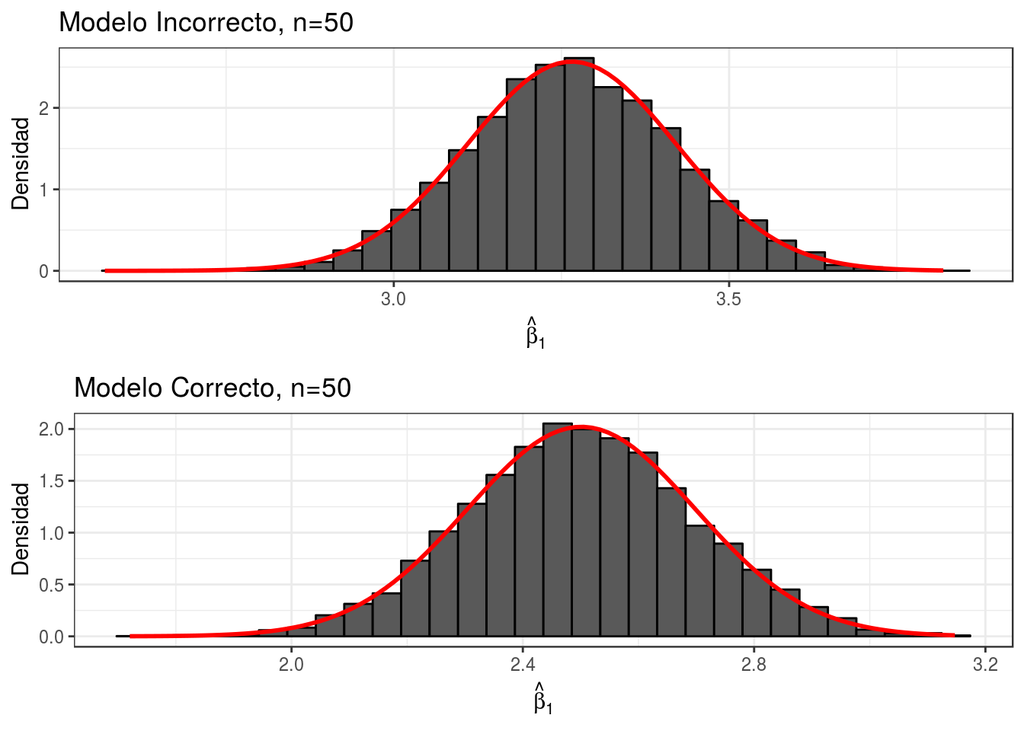

```r
g1_1=ggplot(betas1_df) +
  geom_histogram(aes(betas1_df[,5],y=..density..), col="black", bins = 30) +
  stat_function(fun = dnorm, args = list(mean=mean(betas1_df[,5]), sd=sd(betas1_df[,5])),
                geom = "line", color="red", size=1) +
  ylab("Densidad") + ggtitle("Modelo Incorrecto, n=50") +xlab(expression(hat(beta)[1])) +
  theme_bw()

g1_2=ggplot(betas1_df) +
  geom_histogram(aes(betas1_df[,13],y=..density..), col="black", bins = 30) +
  stat_function(fun = dnorm, args = list(mean=mean(betas1_df[,13]), sd=sd(betas1_df[,13])),
                geom = "line", color="red", size=1) +
  ylab("Densidad") + ggtitle("Modelo Correcto, n=50") +xlab(expression(hat(beta)[1])) +
  theme_bw()

g1=grid.arrange(g1_1, g1_2, ncol=1)
```

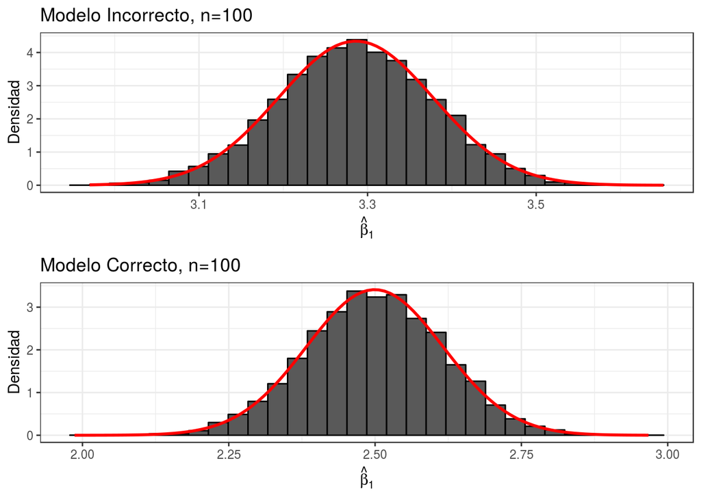

```r
g2_1=ggplot(betas1_df) +
  geom_histogram(aes(betas1_df[,6],y=..density..), col="black", bins = 30) +
  stat_function(fun = dnorm, args = list(mean=mean(betas1_df[,6]), sd=sd(betas1_df[,6])),
                geom = "line", color="red", size=1) +
  ylab("Densidad") + ggtitle("Modelo Incorrecto, n=100") +xlab(expression(hat(beta)[1])) +
  theme_bw()

g2_2=ggplot(betas1_df) +
  geom_histogram(aes(betas1_df[,14],y=..density..), col="black", bins = 30) +
  stat_function(fun = dnorm, args = list(mean=mean(betas1_df[,14]), sd=sd(betas1_df[,14])),
                geom = "line", color="red", size=1) +
  ylab("Densidad") + ggtitle("Modelo Correcto, n=100") +xlab(expression(hat(beta)[1])) +
  theme_bw()

g2= grid.arrange(g2_1, g2_2, ncol=1)
```

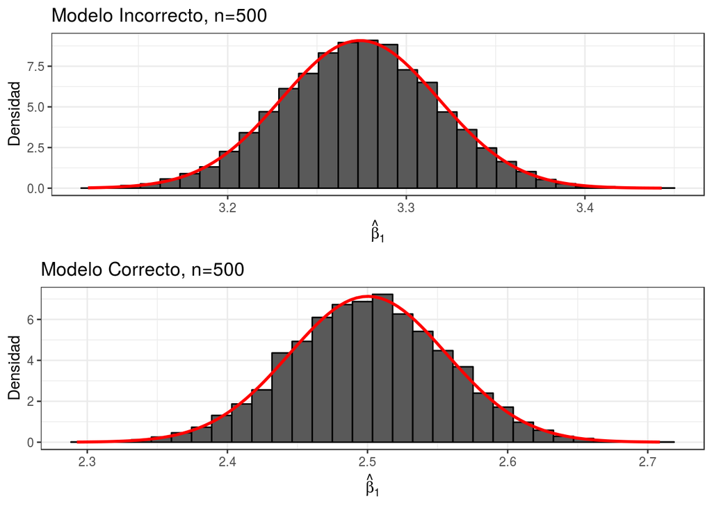

```r
g3_1=ggplot(betas1_df) +
  geom_histogram(aes(betas1_df[,7],y=..density..), col="black", bins = 30) +
  stat_function(fun = dnorm, args = list(mean=mean(betas1_df[,7]), sd=sd(betas1_df[,7])),
                geom = "line", color="red", size=1) +
  ylab("Densidad") + ggtitle("Modelo Incorrecto, n=500") +xlab(expression(hat(beta)[1])) +
  theme_bw()

g3_2=ggplot(betas1_df) +
  geom_histogram(aes(betas1_df[,15],y=..density..), col="black", bins = 30) +
  stat_function(fun = dnorm, args = list(mean=mean(betas1_df[,15]), sd=sd(betas1_df[,15])),
                geom = "line", color="red", size=1) +
  ylab("Densidad") + ggtitle("Modelo Correcto, n=500") +xlab(expression(hat(beta)[1])) +
  theme_bw()

g3= grid.arrange(g3_1, g3_2, ncol=1)
```

[figure not shown]

```r
g4_1=ggplot(betas1_df) +
  geom_histogram(aes(betas1_df[,16],y=..density..), col="black", bins = 30) +
  stat_function(fun = dnorm, args = list(mean=mean(betas1_df[,16]), sd=sd(betas1_df[,16])),
                geom = "line", color="red", size=1) +
  ylab("Densidad") + ggtitle("Modelo Incorrecto, n=1000") +xlab(expression(hat(beta)[1])) +
  theme_bw()


g4_2=ggplot(betas1_df) +
  geom_histogram(aes(betas1_df[,16],y=..density..), col="black", bins = 30) +
  stat_function(fun = dnorm, args = list(mean=mean(betas1_df[,16]), sd=sd(betas1_df[,16])),
                geom = "line", color="red", size=1) +
  ylab("Densidad") + ggtitle("Modelo Correcto, n=1000") +xlab(expression(hat(beta)[1])) +
  theme_bw()
g4= grid.arrange(g4_1, g4_2, ncol=1)
```

[figure not shown]

```r
grid.arrange(g1, g2, g3, g4, ncol=2)
```

A partir de los graficos es posible advertir como los valores muestrales, comienzan a centrarse en su esperanza o valor poblacional. Sin embargo para el caso del “Modelo Incorrecto” se tiende a un $\hat{beta_1}$ equivocado, con esto podemos ratificar el no cumplimiento de la consistencia de los estimadores.

## Parte c

### 0.0.2 Varianza y Media

```r
apply(betas2_df, 2, mean)
```

```
##   X50_b0_M2I  X100_b0_M2I  X500_b0_M2I X1000_b0_M2I   X50_b1_M2I
##     1.540282     3.243931     2.651089     2.551438     2.548537
##  X100_b1_M2I  X500_b1_M2I X1000_b1_M2I   X50_b0_M2C  X100_b0_M2C
##     2.463149     2.493379     2.497205     1.992498     1.999461
##  X500_b0_M2C X1000_b0_M2C   X50_b1_M2C  X100_b1_M2C  X500_b1_M2C
##     2.004367     2.004501     2.500255     2.499884     2.499790
## X1000_b1_M2C
##     2.499800
```

```r
apply(betas2_df, 2, var)
```

```
##   X50_b0_M2I  X100_b0_M2I  X500_b0_M2I X1000_b0_M2I   X50_b1_M2I
## 9.7122802563 3.3415952682 0.7720465626 0.3902799814 0.0241378923
##  X100_b1_M2I  X500_b1_M2I X1000_b1_M2I   X50_b0_M2C  X100_b0_M2C
## 0.0084395227 0.0019305850 0.0009726664 9.7599558048 3.5573270631
##  X500_b0_M2C X1000_b0_M2C   X50_b1_M2C  X100_b1_M2C  X500_b1_M2C
## 0.7795183397 0.3930967270 0.0247355378 0.0086298449 0.0019300555
## X1000_b1_M2C
## 0.0009725421
```

En esta oprtunidad se cambia la distribución de la variable $X_2$, la cual se distribuye $U\sim(0,1)$. En este caso, tanto el modelo correcto como incorrecto convergen al valor poblacional de $\hat{\beta}$. Respecto a las varianzas, para el modelo incorrecto estas serán iguales, en cambio en el caso del modelo correcto serán semejantes. En ambos casos son descendentes y cuando $n \to \infty$, estas serán 0.

### 0.0.3 Graficos

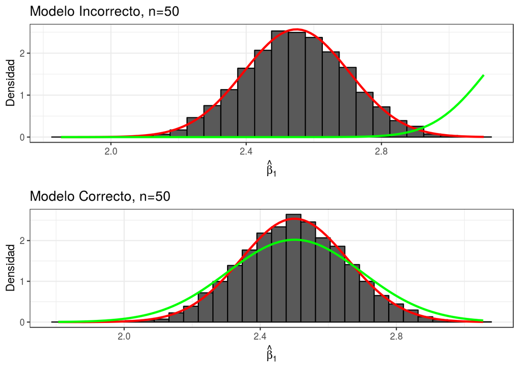

```r
g5_1=ggplot(betas2_df) +
  geom_histogram(aes(betas2_df[,5],y=..density..), col="black", bins =30,  binwidth = 0.05) +
  stat_function(fun = dnorm, args = list(mean=mean(betas2_df[,5]), sd=sd(betas2_df[,5])),
                geom = "line", color="red", size=1) +
  ylab("Densidad") + ggtitle("Modelo Incorrecto, n=50") +xlab(expression(hat(beta)[1])) +
  theme_bw()

g5_1= g5_1 +  stat_function(fun = dnorm, args = list(mean=mean(betas1_df[,5]), sd=sd(betas1_df[,5])),
                      geom = "line", color="green", size=1)
g5_2=ggplot(betas2_df) +
  geom_histogram(aes(betas2_df[,13],y=..density..), col="black", bins = 30) +
  stat_function(fun = dnorm, args = list(mean=mean(betas2_df[,13]), sd=sd(betas2_df[,13])),
                geom = "line", color="red", size=1) +
  ylab("Densidad") + ggtitle("Modelo Correcto, n=50") +xlab(expression(hat(beta)[1])) +
  theme_bw()

g5_2= g5_2+ stat_function(fun = dnorm, args = list(mean=mean(betas1_df[,13]), sd=sd(betas1_df[,13])),
                          geom = "line", color="green", size=1)

g5= grid.arrange(g5_1, g5_2, ncol=1)
```

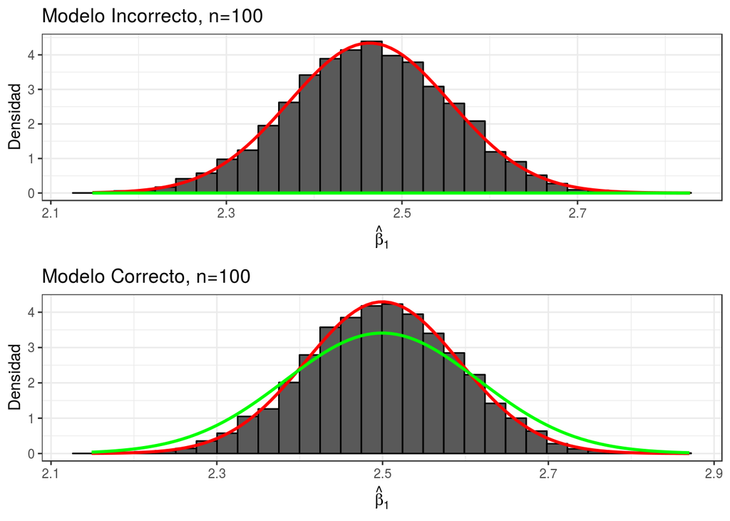

```r
g6_1=ggplot(betas2_df) +
  geom_histogram(aes(betas2_df[,6],y=..density..), col="black", bins = 30) +
  stat_function(fun = dnorm, args = list(mean=mean(betas2_df[,6]), sd=sd(betas2_df[,6])),
                geom = "line", color="red", size=1) +
  ylab("Densidad") + ggtitle("Modelo Incorrecto, n=100") +xlab(expression(hat(beta)[1])) +
  theme_bw()

g6_1= g6_1 +  stat_function(fun = dnorm, args = list(mean=mean(betas1_df[,6]), sd=sd(betas1_df[,6])),
                            geom = "line", color="green", size=1)

g6_2=ggplot(betas2_df) +
  geom_histogram(aes(betas2_df[,14],y=..density..), col="black", bins = 30) +
  stat_function(fun = dnorm, args = list(mean=mean(betas2_df[,14]), sd=sd(betas2_df[,14])),
                geom = "line", color="red", size=1) +
  ylab("Densidad") + ggtitle("Modelo Correcto, n=100") +xlab(expression(hat(beta)[1])) +
  theme_bw()

g6_2= g6_2 +  stat_function(fun = dnorm, args = list(mean=mean(betas1_df[,14]), sd=sd(betas1_df[,14])),
                            geom = "line", color="green", size=1)


g6= grid.arrange(g6_1, g6_2, ncol=1)
```

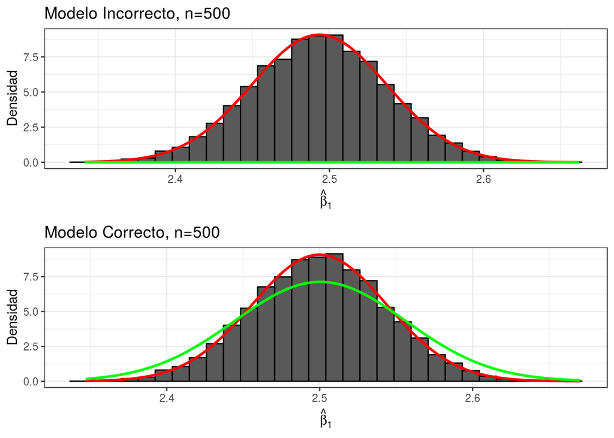

```r
g7_1=ggplot(betas2_df) +
  geom_histogram(aes(betas2_df[,7],y=..density..), col="black", bins = 30) +
  stat_function(fun = dnorm, args = list(mean=mean(betas2_df[,7]), sd=sd(betas2_df[,7])),
                geom = "line", color="red", size=1) +
  ylab("Densidad") + ggtitle("Modelo Incorrecto, n=500") +xlab(expression(hat(beta)[1])) +
  theme_bw()

g7_1= g7_1 +  stat_function(fun = dnorm, args = list(mean=mean(betas1_df[,7]), sd=sd(betas1_df[,7])),
                            geom = "line", color="green", size=1)

g7_2=ggplot(betas2_df) +
  geom_histogram(aes(betas2_df[,15],y=..density..), col="black", bins = 30) +
  stat_function(fun = dnorm, args = list(mean=mean(betas2_df[,15]), sd=sd(betas2_df[,15])),
                geom = "line", color="red", size=1) +
  ylab("Densidad") + ggtitle("Modelo Correcto, n=500") +xlab(expression(hat(beta)[1])) +
  theme_bw()

g7_2= g7_2 +  stat_function(fun = dnorm, args = list(mean=mean(betas1_df[,15]), sd=sd(betas1_df[,15])),
                            geom = "line", color="green", size=1)

g7= grid.arrange(g7_1, g7_2, ncol=1)
```

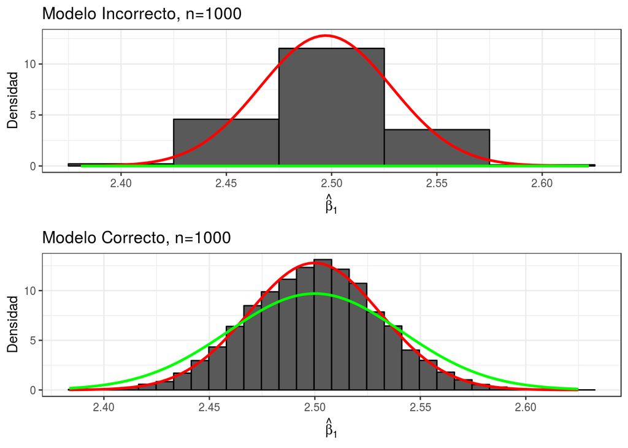

```r
g8_1=ggplot(betas2_df) +
  geom_histogram(aes(betas2_df[,8],y=..density..), col="black", bins = 30,  binwidth = 0.05) +
  stat_function(fun = dnorm, args = list(mean=mean(betas2_df[,8]), sd=sd(betas2_df[,8])),
                geom = "line", color="red", size=1) +
  ylab("Densidad") + ggtitle("Modelo Incorrecto, n=1000") +xlab(expression(hat(beta)[1])) +
  theme_bw()
g8_1= g8_1 +  stat_function(fun = dnorm, args = list(mean=mean(betas1_df[,8]), sd=sd(betas1_df[,8])),
                            geom = "line", color="green", size=1)

g8_2=ggplot(betas2_df) +
  geom_histogram(aes(betas2_df[,16],y=..density..), col="black", bins = 30) +
  stat_function(fun = dnorm, args = list(mean=mean(betas2_df[,16]), sd=sd(betas2_df[,16])),
                geom = "line", color="red", size=1) +
  ylab("Densidad") + ggtitle("Modelo Correcto, n=1000") +xlab(expression(hat(beta)[1])) +
  theme_bw()

g8_2 = g8_2 +  stat_function(fun = dnorm, args = list(mean=mean(betas1_df[,16]), sd=sd(betas1_df[,16])),
                             geom = "line", color="green", size=1)

g8= grid.arrange(g8_1, g8_2, ncol=1)
```

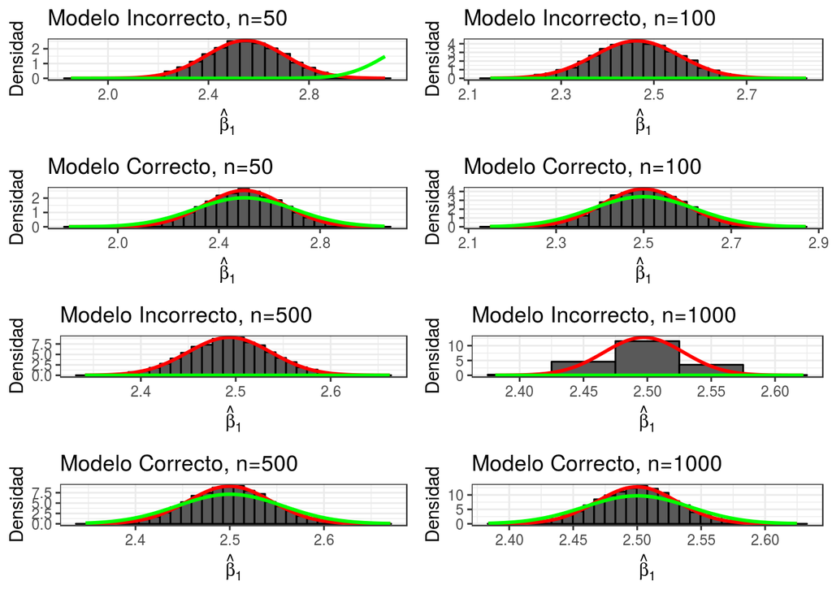

```r
grid.arrange(g5, g6, g7, g8, ncol=2)
```